# perceptual decisions: Cas Ludwig

## Exercise 01: Simulation

Simulate pairs of responses: one from the *preferred* direction (signal) distribution, one from the *non-preferred* direction (noise) distribution.

If signal > noise, response is correct.

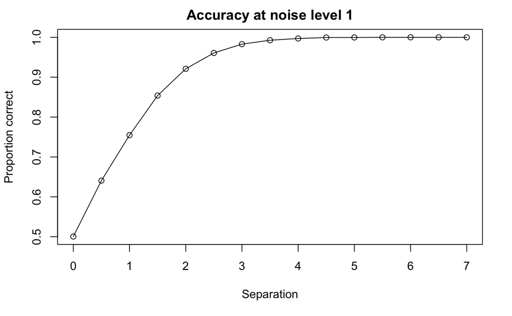

```r
noise = 1
n= 10000
separation = seq(0,7,0.5)
results = NULL
counter = 1
for (i in separation){
  correct = rnorm(n, mean = 0 + i, sd = noise)
  incorrect = rnorm(n, mean = 0, sd = noise)

  results$PC[counter] = mean(correct - incorrect >0)

  results$noise[counter] = noise
  results$separation[counter] = i

  counter = counter +1
}
# Plot
plot(results$separation, results$PC,
     main=paste0("Accuracy at noise level ", noise),
     xlab = "Separation",
     ylab = "Proportion correct")
lines(results$separation, results$PC)
```

*MAX Rule*: whether (signal - noise > 0)…

## Direct Evaluation

*Cannot be directly evaluated - need to be integreated numerically.*

- Integrates across all possible noise responses and evaluate the probability that the signal response was greater.
- This results in a more complex expression to integrate, but the result should be identical to the difference distribution.
- The advantage of this approach is that it scales up for designs with more than two alternatives.

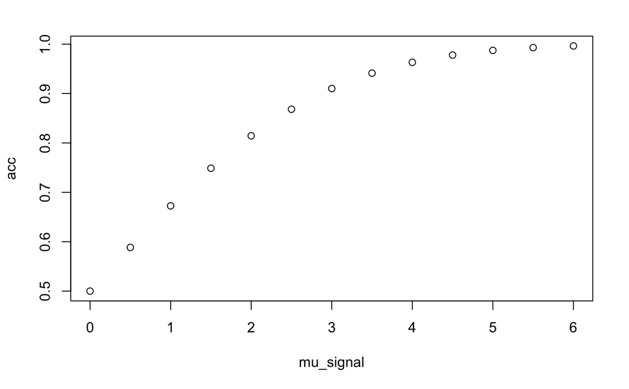

## TOURNAMENT

- Develop a mechanistic model of the psychometric function
- Fit model to behavioural data using MLE or use Bayes if you like :-)
- Fit data on a training set
- Outcome metric: predictive generalisation to test set (i.e. likelihood of the “un-seen” test data)
- It may be instructive to compute other metrics for model selection (e.g. AIC, BIC)

#### Use Direct Evaluation

For a given target response u = Xsignal, compute probability that all (M-1) distractor response are less than u.

- Fit model to each participant
- Sum deviance measures across participants to get overall model fit

```r
load("resources/TrainData.csv")
```

[output not shown]

### Improving the model

- Non-linear transducer (e.g. log, power, Naka-Rushton)
- Signal-dependent noise (e.g. sig^2 = 1 + k*u)
- Mixture of visually guided resopnses and stimulus-independent responses (“finger errors”)

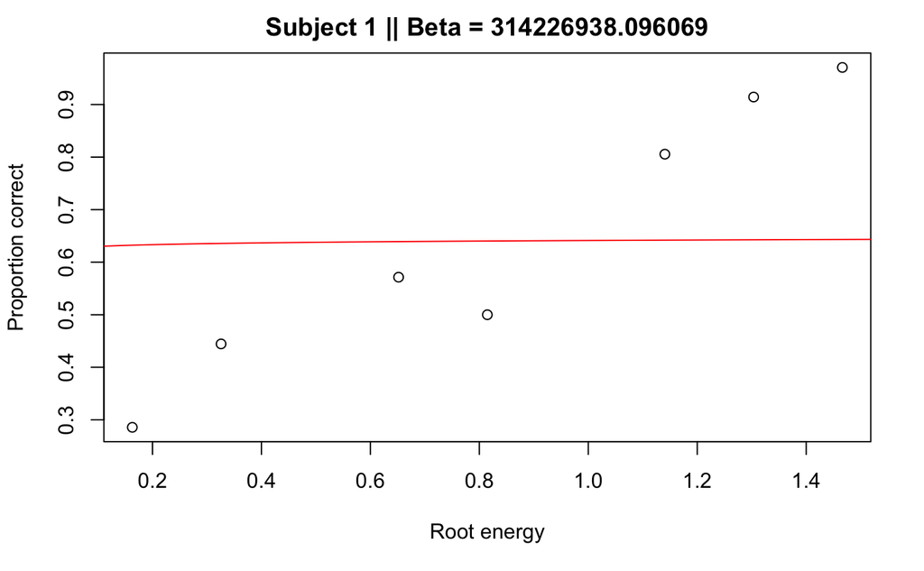

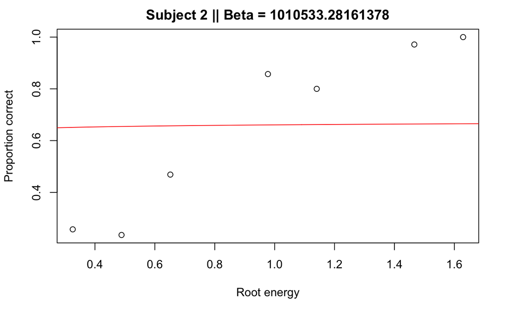

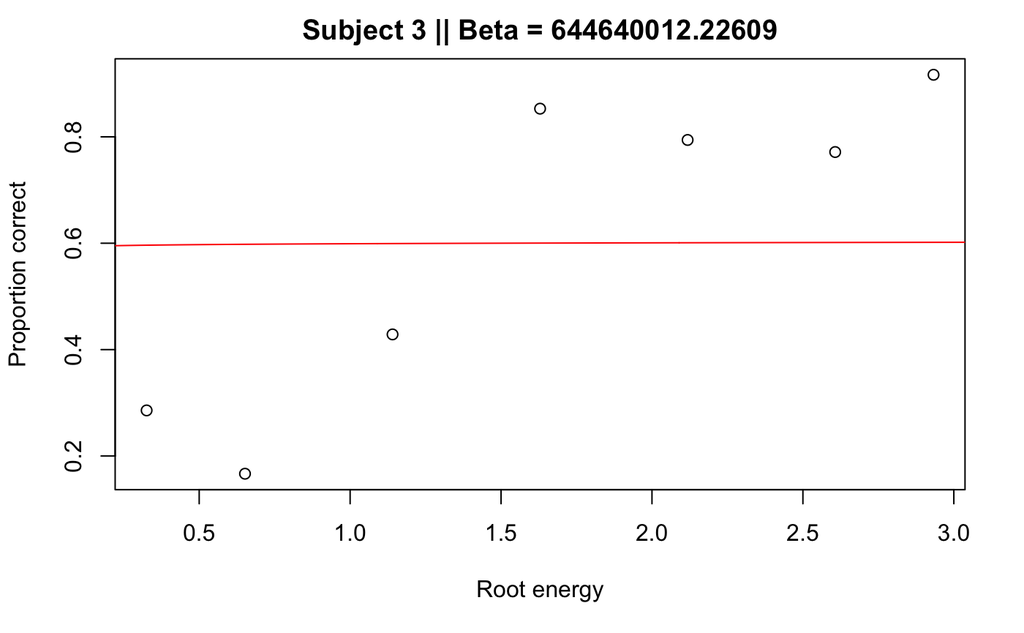

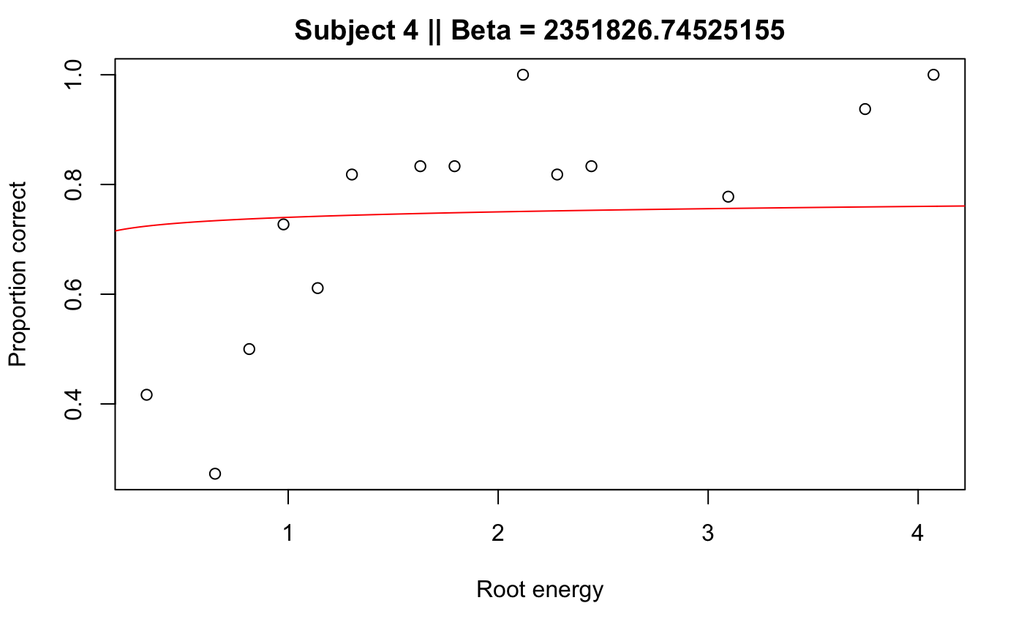

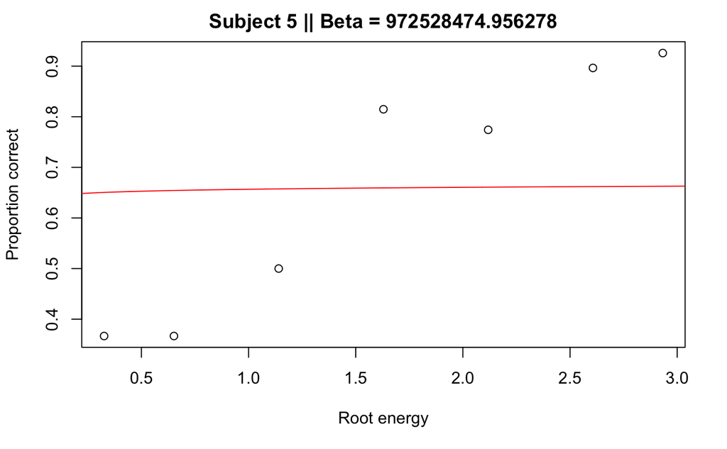

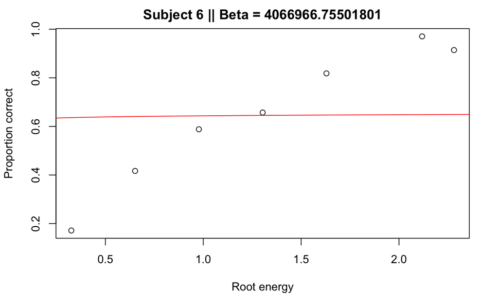

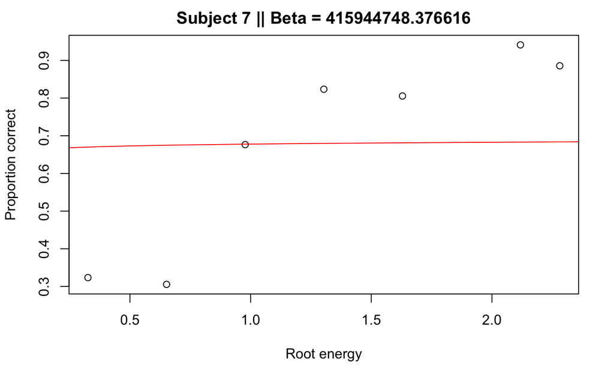

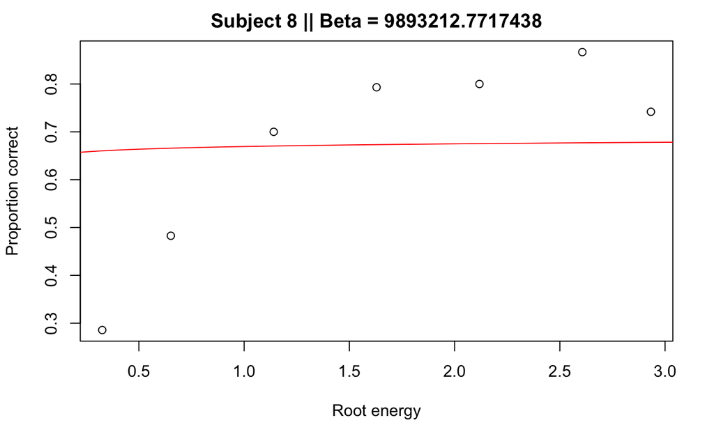

### ALT FIT

```r
# PC_MAFC computes the predicted proportion correct for a single signal level.
PC_MAFC<-function(mu_signal,mu_noise=0,sigma=1){
  # Define the function to be integrated
  MAFCmax<-function(x,mean1=0,mean2=0,sd1=1,sd2=1,M=2) dnorm(x,mean=mean1,sd=sd1)*(pnorm(x,mean=mean2,sd=sd2))^(M-1)

  Mstar<-4
  # This function can only be numerically integrated. You can be more or less
  # sophisticated about this. I'm using the built-in 'integrate'
  # function.
  lowlim<-mu_noise-5*sigma # Set some sensible integration limits
  uplim<-mu_signal+5*sigma # Assumes: mu_noise <= mu_signal

  PC<-integrate(MAFCmax,
               lowlim,
               uplim,
               mean1=mu_signal,
               mean2=mu_noise,
               sd1=sigma,
               sd2=sigma,
               M=Mstar)
  PC_MAFCval<-PC$value
  return(PC_MAFCval)
}

# Write the error function that returns the deviance for a single subject
MyModel<-function(parms,PFdata){
  beta<-parms[1]
  sdnoise<-1
  deviance = 0

  # pass contrast levels through the transducer
  for (level in 1:length(PFdata$rootEnergy)){
    signal= PFdata$rootEnergy[level] * beta
    # For each signal level, compute the predicted PC (hint: check the apply family)
    PC = dbinom(PFdata$Ncorrect, PFdata$Ntrials, PC_MAFC(signal, mu_noise=0, sigma=1))
    # Once you have your predictions, compute the log-likelihoods and the Deviance

    deviance = deviance + sum(log(PC))
  }

  MyDeviance = -2 * deviance

  return(MyDeviance)
}

# Load the data file and turn Participant into a factor

PFdata = read.csv("resources/TrainData.csv")
PFdata$Participant = factor(PFdata$Participant)

# One method is to use a for-loop. On each iteration, you select data from one participant and then call optim(ize) with 'MyModel' as the function to be minimised.

parms = c(1)

fit = matrix(nrow = 8, ncol = 6)
colnames(fit) <- c('subject', 'deviance', 'beta_est', 1, 2, 3)

for (i in 1:length(unique(PFdata$Participant))){
  dat = PFdata[PFdata$Participant==i,]

  output = optim(par = parms, fn = MyModel, PFdata = dat)

  fit[i,1] = i
  fit[i,2] = output$value
  fit[i,3] = output$par
}


# Another method is to create a separate function that takes in a dataframe and calls optim(ize). You could then use this function in an apply-like statement to loop through the participants. If you have do not have a firm grasp on what these apply functions do, I suggest you stick with a for-loop.

# Try to do the fitting and end up with all the model parameters in a 8 x K data frame.

# Plot the results: observed data and model predictions superimposed. Do this separately for each subject, so you can see the quality of your fits.
par(c(2,2))

for (i in 1:8){
  dat = PFdata[PFdata$Participant==i,]

  y_act = dat$Ncorrect/dat$Ntrials
  x = dat$rootEnergy

  xs = seq(0,max(dat$rootEnergy)+0.2,0.01)
  y_est = xs*fit[i,3]

  y_est_p = lapply(y_est, FUN = PC_MAFC)

  #actual data
  plot(x,y_act,
       main = paste0('Subject ',i, ' || Beta = ', fit[i,3]),
       ylab = 'Proportion correct',
       xlab = 'Root energy')
  #estimated data
  lines(xs,y_est_p,
        col="red")
}
```